# Getting Started

## Imports

```julia
using GeoDataAccess
using GeoDataAccess: DataAccessPlan, fetch, MetaData
using Dates
```

## Discovering Sources

GeoDataAccess ships with several data sources. Use `all_sources` and `available_sources` to see what’s registered:

```julia
all_sources()
```

```
15-element Vector{GeoDataAccess.AbstractDataSource}:
 OpenMeteoArchive()
 OpenMeteoForecast()
 NOAANCEI("daily-summaries")
 NASAPower()
 TomorrowIO()
 VisualCrossing()
 GeoDataAccess.USGSEarthquake()
 USGSWaterServices("dv")
 GeoDataAccess.OpenAQ()
 GeoDataAccess.NASAFIRMS()
 GeoDataAccess.EPAAQS()
 GeoDataAccess.NOAAGFS()
 GeoDataAccess.ERA5()
 GeoDataAccess.CopernicusDEM(30)
 GeoDataAccess.OpenStreetMap()
```

```julia
# Only sources you can use right now (API key set or not required)
available_sources()
```

```
9-element Vector{GeoDataAccess.AbstractDataSource}:
 OpenMeteoArchive()
 OpenMeteoForecast()
 NOAANCEI("daily-summaries")
 NASAPower()
 GeoDataAccess.USGSEarthquake()
 USGSWaterServices("dv")
 GeoDataAccess.NOAAGFS()
 GeoDataAccess.CopernicusDEM(30)
 GeoDataAccess.OpenStreetMap()
```

Every source carries a `MetaData` record describing its coverage, resolution, variables, and access requirements:

```julia
MetaData(NASAPower())
```

```
MetaData("", "No published rate limit", GeoDataAccess.Weather, Dict(:WD2M => "Wind direction at 2m (°)", :PRECTOTCORR => "Precipitation corrected (mm/day)", :CLOUD_AMT => "Cloud amount (%)", :CLRSKY_SFC_SW_DWN => "Clear-sky surface shortwave downward irradiance (MJ/m²/day)", :ALLSKY_SFC_SW_DWN => "A…
```

```julia
MetaData(OpenMeteoArchive())
```

```
MetaData("", "10,000 calls/day (non-commercial)", GeoDataAccess.Weather, Dict(:temperature_2m_mean => "Daily mean temperature at 2m (°C)", :wind_direction_10m_dominant => "Daily dominant wind direction (°)", :apparent_temperature_max => "Daily maximum apparent temperature (°C)", :surface_pressure =>…
```

## Plan / Fetch Workflow

Every data request follows two steps:

1. **Plan** — `DataAccessPlan(source, extent, start_date, stop_date; kw...)` builds a plan describing the API calls that will be made, without executing them.
2. **Fetch** — `fetch(plan)` executes the plan, downloads data, and returns file paths to cached JSON files.

The interface is the same regardless of which source you choose.

### Step 1: Create a Plan

Pass a data source, a location `(longitude, latitude)`, a date range, and the variables you want. Each source has its own variable names — check its `MetaData` or documentation page for the list.

```julia
# NASA POWER — daily temperature and precipitation
plan = DataAccessPlan(NASAPower(), (-74.0, 40.7),
    Date(2024, 7, 1), Date(2024, 7, 14);
    variables = [:T2M, :PRECTOTCORR])
```

```
DataAccessPlan for nasapower
  Extent:    Point(40.7, -74.0)
  Time:      2024-07-01 to 2024-07-14 (14 days)
  Variables: T2M, PRECTOTCORR
  community: AG
  query_type: point
  API calls: 1
  Est. size: 224 bytes

  Request 1: GET Point(40.7, -74.0), 14 days → nasapower/f4aeeed25010a44.json
```

The plan shows you exactly what will be fetched — number of API calls, estimated size, time range, and variables — before any network requests are made.

### Step 2: Fetch the Data

```julia
files = fetch(plan)
```

```
1-element Vector{String}:
 "/home/runner/.julia/scratchspac" ⋯ 60 bytes ⋯ "nasapower/f4aeeed25010a44.json"
```

`fetch` returns a vector of file paths to cached JSON files. Read them with JSON.jl:

```julia
using JSON

data = JSON.parsefile(files[1])
collect(keys(data))
```

```
7-element Vector{String}:
 "type"
 "geometry"
 "properties"
 "header"
 "messages"
 "parameters"
 "times"
```

### Shortcut: `fetch` Directly

You can also skip the plan and call `fetch` directly on a source:

```julia
files = fetch(NASAPower(), (-74.0, 40.7),
    Date(2024, 7, 1), Date(2024, 7, 14);
    variables = [:T2M, :PRECTOTCORR])
```

```
1-element Vector{String}:
 "/home/runner/.julia/scratchspac" ⋯ 60 bytes ⋯ "nasapower/f4aeeed25010a44.json"
```

### Same Workflow, Any Source

The plan/fetch pattern works identically across all sources. Only the source constructor and variable names change:

```julia
# Open-Meteo Archive — hourly data with different variable names
plan = DataAccessPlan(OpenMeteoArchive(), (-74.0, 40.7),
    Date(2024, 7, 1), Date(2024, 7, 14);
    variables = [:temperature_2m, :precipitation],
    frequency = :hourly)
```

```
DataAccessPlan for openmeteoarchive
  Extent:    Point(40.7, -74.0)
  Time:      2024-07-01 to 2024-07-14 (14 days)
  Variables: temperature_2m, precipitation
  frequency: hourly
  timezone: GMT
  API calls: 1
  Est. size: 5.250 KiB

  Request 1: GET 1 point(s), hourly 14 days → openmeteoarchive/d24c1282ace1ab86.json
```

```julia
# NOAA NCEI — station-based, requires station IDs
plan = DataAccessPlan(NOAANCEI(), (-74.0, 40.7),
    Date(2024, 7, 1), Date(2024, 7, 14);
    stations = ["USW00094728"],
    variables = [:TMAX, :TMIN, :PRCP])
```

```
DataAccessPlan for noaancei
  Extent:    1 station(s): USW00094728
  Time:      2024-07-01 to 2024-07-14 (14 days)
  Variables: TMAX, TMIN, PRCP
  stations: ["USW00094728"]
  API calls: 1
  Est. size: 336 bytes

  Request 1: GET 1 station(s), 14 days → noaancei/a0665c46cb739385.json
```

See the **Data Sources** section in the sidebar for source-specific details, examples, and variable listings.

## Example: Comparing Sources

Fetch daily temperature from two independent sources for the same location and overlay them:

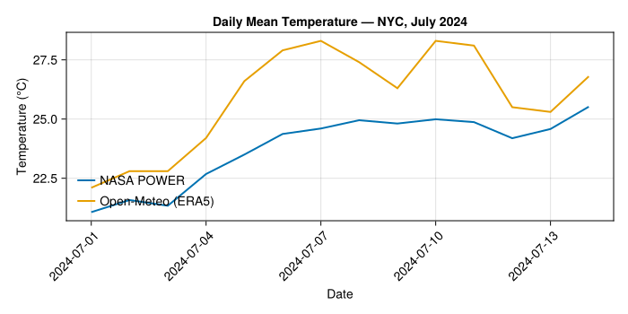

```julia
using CairoMakie

# NASA POWER
files_power = fetch(NASAPower(), (-74.0, 40.7),
    Date(2024, 7, 1), Date(2024, 7, 14);
    variables = [:T2M])
power = JSON.parsefile(files_power[1])
power_temps = collect(values(power["properties"]["parameter"]["T2M"]))
power_dates = Date.(collect(keys(power["properties"]["parameter"]["T2M"])), "yyyymmdd")

# Open-Meteo Archive
files_meteo = fetch(OpenMeteoArchive(), (-74.0, 40.7),
    Date(2024, 7, 1), Date(2024, 7, 14);
    variables = [:temperature_2m_mean], frequency = :daily)
meteo = JSON.parsefile(files_meteo[1])
meteo_temps = meteo["daily"]["temperature_2m_mean"]
meteo_dates = Date.(meteo["daily"]["time"])

fig = Figure(size=(700, 350))
ax = Axis(fig[1, 1];
    xlabel="Date", ylabel="Temperature (°C)",
    title="Daily Mean Temperature — NYC, July 2024",
    xticklabelrotation=pi/4)
lines!(ax, power_dates, power_temps; label="NASA POWER", linewidth=2)
lines!(ax, meteo_dates, meteo_temps; label="Open-Meteo (ERA5)", linewidth=2)
axislegend(ax; position=:lb, framevisible=false)
fig
```

## GeoInterface Integration

`DataAccessPlan` accepts any GeoInterface.jl-compatible geometry as the spatial extent. The geometry type determines how coordinates are sent to the API:

| Geometry | Behavior |
| --- | --- |
| `Point` / `Tuple` | Single coordinate query |
| `MultiPoint` | One query per point |
| `LineString` | One query per vertex |
| `Polygon` | Bounding box / corner point queries |
| `Extent` | Bounding box / corner point queries |

### Multi-Point Query

```julia
import GeoInterface as GI

mp = GI.MultiPoint([(-74.0, 40.7), (-87.6, 41.9)])

plan = DataAccessPlan(NASAPower(), mp,
    Date(2024, 1, 1), Date(2024, 1, 7);
    variables = [:T2M])
plan
```

```
DataAccessPlan for nasapower
  Extent:    2 points
  Time:      2024-01-01 to 2024-01-07 (7 days)
  Variables: T2M
  community: AG
  query_type: multi_point
  API calls: 2
  Est. size: 112 bytes

  Request 1: GET Point(40.7, -74.0), 7 days → nasapower/c378f65586265649.json
  Request 2: GET Point(41.9, -87.6), 7 days → nasapower/ce8f13f38b3cb8e.json
```

### Extent Query

```julia
using GeoInterface.Extents: Extent

ext = Extent(X=(-76.0, -72.0), Y=(39.0, 42.0))

plan = DataAccessPlan(NASAPower(), ext,
    Date(2024, 1, 1), Date(2024, 1, 7);
    variables = [:T2M])
plan
```

```
DataAccessPlan for nasapower
  Extent:    Extent(X=(-76.0, -72.0), Y=(39.0, 42.0))
  Time:      2024-01-01 to 2024-01-07 (7 days)
  Variables: T2M
  community: AG
  query_type: regional
  API calls: 1
  Est. size: 56 bytes

  Request 1: GET Regional bbox, 7 days → nasapower/4ec2c52b8c5be1bf.json
```